# Predicting eBook Revenue

STAT 330 Portfolio Project Proposal

Author

Kailyn Eastman, Brielle Giles, Jane Callister

## Question and audience

We want to investigate how genre, publisher type, seller, rating, total reviews, daily average gross sales and sale price affect average daily author revenues book sales; specifically related to e-books. In doing so, we want to predict average daily author revenue based on certain predictor values, as listed above. This will help us determine which variables an author should consider to achieve higher average daily revenue from their e-book sales. Our audience is prospective e-book authors who want to understand the variables that go into increasing their daily revenue.

## Data

Source Link: https://corgis-edu.github.io/corgis/csv/publishers/

```r
#  Loading Library
library(tidyverse)

#  Reading in Data
publishers_data <- read.csv("publishers.csv", header = T)

# Rename the predictors
publishers_data <- publishers_data |>
  rename(
    author_revenue = daily.average.author.revenue,
    seller = sold.by,
    amazon_revenue = daily.average.amazon.revenue,
    gross_sales = daily.average.gross.sales,
    publisher_revenue = daily.average.publisher.revenue,
    units_sold = daily.average.units.sold,
    publisher_name = publisher.name,
    publisher_type = publisher.type,
    average_rating = statistics.average.rating,
    sale_price = statistics.sale.price,
    sales_rank = statistics.sales.rank,
    total_reviews = statistics.total.reviews
  )

# Combine HarperCollins Publishers and Publishing (same seller)
publishers_data <- publishers_data |>
  mutate(
    seller = recode(
      seller,
      "HarperCollins Publishers" = "HarperCollins Publishing"
    )
  )

#
publishers_data <- publishers_data |>
  mutate(
    genre = as.factor(genre),
    seller = as.factor(seller),
    publisher_type = as.factor(publisher_type),
    publisher_name = as.factor(publisher_name)
  )

#  Checking Data by headers
head(publishers_data)
```

```
          genre                         seller amazon_revenue author_revenue
1 genre fiction       HarperCollins Publishing         6832.0         6832.0
2 genre fiction       HarperCollins Publishing         2487.5         2487.5
3 genre fiction Amazon Digital Services,  Inc.         9559.0         9559.0
4       fiction            Hachette Book Group         8250.0         8250.0
5 genre fiction        Penguin Group (USA) LLC         7590.5         7590.5
6 genre fiction Amazon Digital Services,  Inc.        12974.0         6986.0
  gross_sales publisher_revenue units_sold              publisher_name
1     34160.0           20496.0       7000       Katherine Tegen Books
2     12437.5            7462.5       6250       HarperCollins e-books
3     47795.0           28677.0       5500 (Small or Medium Publisher)
4     41250.0           24750.0       5500   Little, Brown and Company
5     37952.5           22771.5       4750           Dutton Children's
6     19960.0               0.0       4000             Thomas & Mercer
  publisher_type average_rating sale_price sales_rank total_reviews
1       big five           4.57       4.88          1          9604
2       big five           4.47       1.99          2           450
3   small/medium           4.16       8.69          3            30
4       big five           3.84       7.50          3          3747
5       big five           4.75       7.99          4          9174
6         amazon           4.05       4.99          5            40
```

```r
#  Checking dimensions
dim(publishers_data)
```

```
[1] 27027    13
```

```r
#  Variables
colnames(publishers_data)
```

```
 [1] "genre"             "seller"            "amazon_revenue"
 [4] "author_revenue"    "gross_sales"       "publisher_revenue"
 [7] "units_sold"        "publisher_name"    "publisher_type"
[10] "average_rating"    "sale_price"        "sales_rank"
[13] "total_reviews"
```

## One useful first look

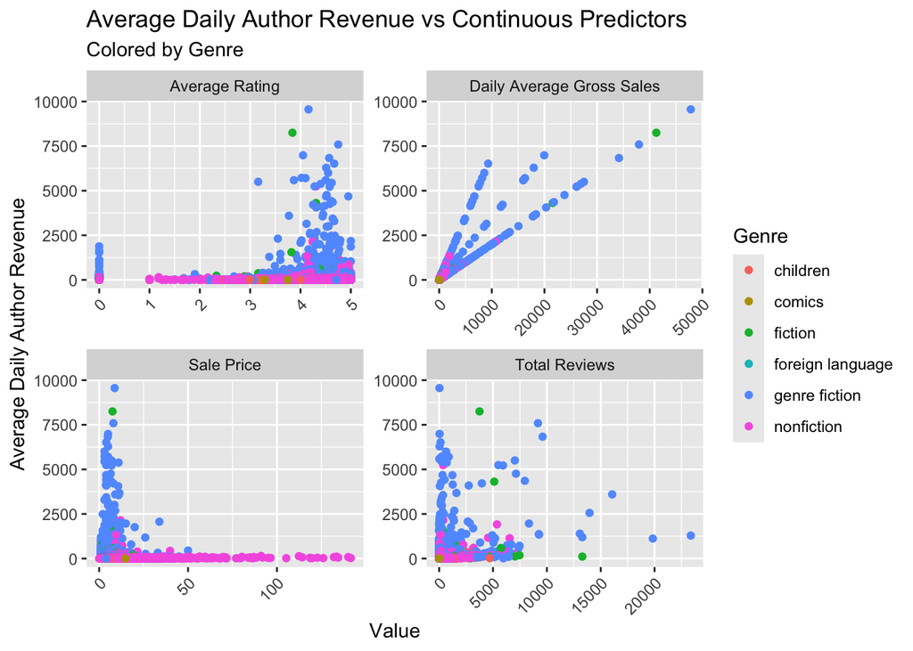

```r
# Continuous variables against genre
publishers_data |>
  pivot_longer(
    cols = c(average_rating, total_reviews, sale_price, gross_sales),
    names_to = "predictor",
    values_to = "value"
  ) |>
  ggplot(aes(x = value, y = author_revenue, color = genre)) +
  geom_point() +
  facet_wrap(
    ~predictor,
    scales = "free",
    labeller = as_labeller(c(
      average_rating = "Average Rating",
      total_reviews = "Total Reviews",
      sale_price = "Sale Price",
      gross_sales = "Daily Average Gross Sales"
    ))
  ) +
  theme(axis.text.x = element_text(angle = 45, hjust = 1)) +
  labs(
    title = "Average Daily Author Revenue vs Continuous Predictors",
    subtitle = "Colored by Genre",
    x = "Value",
    y = "Average Daily Author Revenue",
    color = "Genre"
  )
```

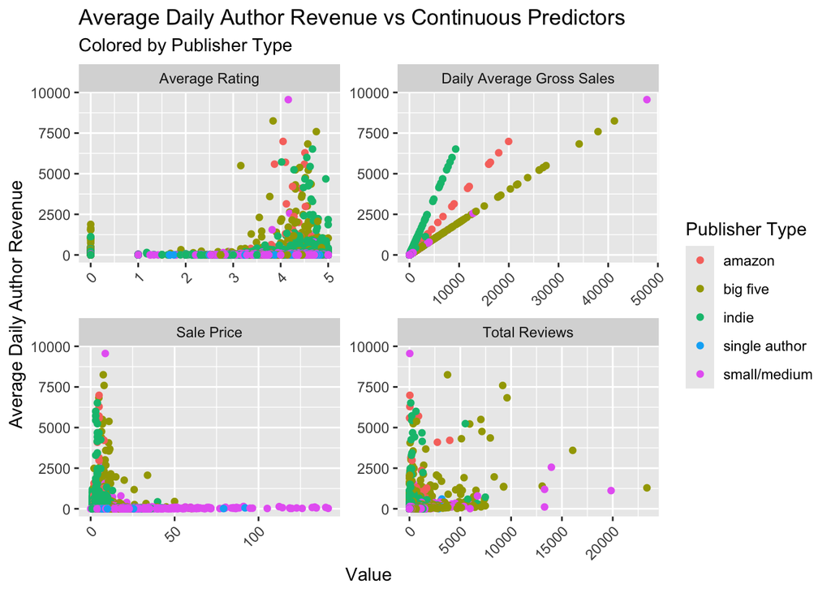

```r
# Continuous variables against publisher type
publishers_data |>
  pivot_longer(
    cols = c(average_rating, total_reviews, sale_price, gross_sales),
    names_to = "predictor",
    values_to = "value"
  ) |>
  ggplot(aes(x = value, y = author_revenue, color = publisher_type)) +
  geom_point() +
  facet_wrap(
    ~predictor,
    scales = "free",
    labeller = as_labeller(c(
      average_rating = "Average Rating",
      total_reviews = "Total Reviews",
      sale_price = "Sale Price",
      gross_sales = "Daily Average Gross Sales"
    ))
  ) +
  theme(axis.text.x = element_text(angle = 45, hjust = 1)) +
  labs(
    title = "Average Daily Author Revenue vs Continuous Predictors",
    subtitle = "Colored by Publisher Type",
    x = "Value",
    y = "Average Daily Author Revenue",
    color = "Publisher Type"
  )
```

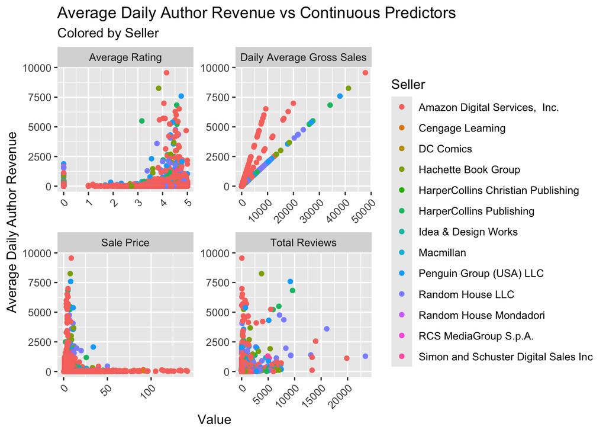

```r
# Continuous variables against sold by
publishers_data |>
  pivot_longer(
    cols = c(average_rating, total_reviews, sale_price, gross_sales),
    names_to = "predictor",
    values_to = "value"
  ) |>
  ggplot(aes(x = value, y = author_revenue, color = seller)) +
  geom_point() +
  facet_wrap(
    ~predictor,
    scales = "free",
    labeller = as_labeller(c(
      average_rating = "Average Rating",
      total_reviews = "Total Reviews",
      sale_price = "Sale Price",
      gross_sales = "Daily Average Gross Sales"
    ))
  ) +
  theme(axis.text.x = element_text(angle = 45, hjust = 1)) +
  labs(
    title = "Average Daily Author Revenue vs Continuous Predictors",
    subtitle = "Colored by Seller",
    x = "Value",
    y = "Average Daily Author Revenue",
    color = "Seller"
  )
```

The most notable patterns among our continuous predictors are observed in average rating and sale price. Higher average daily author revenue tends to be associated with higher average ratings, while lower revenue is generally associated with lower ratings. However, most books are concentrated in the lower-revenue range. Sale prices are relatively similar across many books, but lower sale prices tend to be associated with higher average daily author revenue. When looking at daily average gross sales, we see a pattern in publisher type—author revenue tends to increase more for indie publishers as opposed to Amazon and big five publishers, shown by a steeper line. When examining the plots by genre, nonfiction books generally generate lower daily author revenue than genre fiction books; when focused on only those genres, as they make up the majority of the observed genres.

## Baseline model

We started with a basic linear regression model to take a first look at the associations and interactions.

```r
# Fit the baseline and display only the output needed below.
starting_mod <- lm(
  author_revenue ~ genre +
    publisher_type +
    average_rating +
    total_reviews +
    sale_price +
    seller +
    gross_sales,
  data = publishers_data
)

summary(starting_mod)
```

```
Call:
lm(formula = author_revenue ~ genre + publisher_type + average_rating +
    total_reviews + sale_price + seller + gross_sales, data = publishers_data)

Residuals:
    Min      1Q  Median      3Q     Max
-1801.2   -10.8     1.6     7.1  4254.2

Coefficients: (1 not defined because of singularities)
                                             Estimate Std. Error t value
(Intercept)                                 4.798e+01  5.217e+00   9.197
genrecomics                                 4.452e+00  4.805e+00   0.927
genrefiction                               -4.714e-01  3.767e+00  -0.125
genreforeign language                      -3.811e+00  8.410e+00  -0.453
genregenre fiction                          1.224e+01  2.053e+00   5.963
genrenonfiction                            -3.100e+00  2.000e+00  -1.550
publisher_typebig five                     -6.997e+01  5.148e+00 -13.592
publisher_typeindie                        -2.408e+01  4.532e+00  -5.313
publisher_typesingle author                -6.690e+01  4.640e+00 -14.416
publisher_typesmall/medium                 -6.832e+01  4.498e+00 -15.189
average_rating                              3.226e+00  5.524e-01   5.840
total_reviews                              -1.455e-02  1.282e-03 -11.348
sale_price                                  3.895e-01  9.638e-02   4.041
sellerCengage Learning                     -5.531e+00  2.985e+01  -0.185
sellerDC Comics                             3.582e+00  9.148e+00   0.392
sellerHachette Book Group                  -1.256e+01  4.519e+00  -2.779
sellerHarperCollins Christian Publishing    2.475e+00  9.511e+00   0.260
sellerHarperCollins Publishing             -2.853e+00  3.630e+00  -0.786
sellerIdea & Design Works                   5.847e-01  1.570e+01   0.037
sellerMacmillan                            -2.410e+00  4.186e+00  -0.576
sellerPenguin Group (USA) LLC              -8.420e+00  3.589e+00  -2.346
sellerRandom House LLC                     -2.114e+00  3.357e+00  -0.630
sellerRandom House Mondadori                7.876e+00  6.323e+01   0.125
sellerRCS MediaGroup S.p.A.                 2.244e+01  8.969e+01   0.250
sellerSimon and Schuster Digital Sales Inc         NA         NA      NA
gross_sales                                 2.375e-01  6.856e-04 346.444
                                           Pr(>|t|)
(Intercept)                                 < 2e-16 ***
genrecomics                                 0.35416
genrefiction                                0.90043
```

[output cut: 14 more lines]

```
sellerHarperCollins Publishing              0.43183
sellerIdea & Design Works                   0.97028
sellerMacmillan                             0.56473
sellerPenguin Group (USA) LLC               0.01897 *
sellerRandom House LLC                      0.52894
sellerRandom House Mondadori                0.90087
sellerRCS MediaGroup S.p.A.                 0.80243
sellerSimon and Schuster Digital Sales Inc       NA
gross_sales                                 < 2e-16 ***
---
Signif. codes:  0 '***' 0.001 '**' 0.01 '*' 0.05 '.' 0.1 ' ' 1

Residual standard error: 89.31 on 27002 degrees of freedom
Multiple R-squared:  0.8402,    Adjusted R-squared:  0.8401
F-statistic:  5917 on 24 and 27002 DF,  p-value: < 2.2e-16
```

## Where the analysis could go

1. We will use LASSO to help us with subset selection. This will enable us to simplify our model to best determine the predictors of average daily author revenue.
2. We will use cross-validation to help determine the prediction accuracy of average daily author revenue in regards to our chosen candidate models.

## AI disclosure and sources

We used AI to help proofread our code and writing.

Works Cited Bart, A. C. (2015). Publishers CSV file (Version 2.0.0) [Data set]. CORGIS Dataset Project. https://corgis-edu.github.io/corgis/csv/publishers/